# Text Mining

# Introduction

During this practical, we will cover an introduction to text mining, this will include how to pre-process mined text, different ways to visualize this the mined text and an introduction to one type of analysis you can conduct during text mining: sentiment analysis. As a whole, there are multiple different ways to analysis mine & analyze text within `R` however for this practical we will be focused on the techniques covered in the `tidytext` package, based upon the `tidyverse`.

For this practical, you will need the following packages:

```r
# General Packages
    library(tidyverse)

# Text Mining
    library(tidytext)
    library(gutenbergr)
    library(SnowballC)
    library(wordcloud)
    library(textdata)
```

For this practical, we will be using text mined through the [Gutenberg Project](https://www.gutenberg.org/wiki/Main_Page); briefly this project contains over 60,000 freely accessible eBooks, which through the package `gutenberger`, can be easily accessed and perfect for text mining and analysis.

During this practical, we will be looking at several books from the late 1800s, in the mindset to compare and contrast the use of language within them. These books include:

- *Alice’s Adventures in Wonderland by Lewis Carroll*
- *The Picture of Dorian Gray by Oscar Wilde*
- *Dracula by Bram Stoker*
- *The Strange Case of Dr. Jekyll and Mr. Hyde by Robert Louis Stevenson*

Despite being from the late 1800s, these books still are popular and hold cultural significance in TV, Movies and the English Language. To access this novel suitable for this practical the following function should be used:

```r
AAIWL <- gutenberg_download(28885) # 28885 is the eBook number of Alice in Wonderland
PODG <- gutenberg_download(174) # 174 is the eBook number of The Picture of Dorian Gray
Drac <- gutenberg_download(345) # 345 is the eBook number of Dracula
SCJH <- gutenberg_download(43) # 43 is the eBook number of Dr. Jekyll and Mr. Hyde
```

After having loaded all of these books into your working directory (using the code above), examine one of these books using the `View()` function. When you view any of these data frames, you will see that these have an extremely *messy* layout and structure. As a result of this complex structure means that conducting *any* analysis would be extremely challenging, so pre-processing must be undertaken to get this into a format which is usable.

# Pre-Processing Text

In order for text to be used effectively within statistical processing and analysis; it must be pre-processed so that it can be uniformly examined. In general the major steps of pre-processing include:

- Removing numbers
- Removing capital letters
- Removing stop words
- Removing inter-punctuation
- Application of a Stemming Algorithm

These steps are important as this allows the text to be presented uniformly for analysis; within this practical we will discuss how to undergo each of these steps using the `tidytext` package.

## Step 1, Un-nesting Text

When we previously looked at this text, as we discovered it was extremely *messy* with it being attached one line per row in the data frame. As such, it is important to un-nest this text so that it attaches one word per row.

Before doing this, it is useful to make a note of aspects such as the line which text is on, and the chapter each line falls within. This can be important when examining anthologies or making chapter comparisons as this can be specified within the analysis.

In order to specify the line number and chapter of the text, it is possible to use the `mutuate` function from the `dplyr` package.

**Question 1. Apply the code below, which uses the `mutate` function, to add line numbers and chapter references one of the books, before using the `View()` function on outcome to examine how this has changed the structure.**

```r
# Template:

tidy_[BOOKNAME] <- [BOOKNAME] %>%
  mutate(linenumber = row_number(),
         chapter = cumsum(str_detect(text, regex("^chapter [\\divxlc]",
                                                 ignore_case = TRUE))))
```

```r
# Answers

tidy_AAIWL <- AAIWL %>%
  mutate(linenumber = row_number(),
         chapter = cumsum(str_detect(text, regex("^chapter [\\divxlc]",
                                                 ignore_case = TRUE))))
tidy_PODG <- PODG %>%
  mutate(linenumber = row_number(),
         chapter = cumsum(str_detect(text, regex("^chapter [\\divxlc]",
                                                 ignore_case = TRUE))))

tidy_Drac <- Drac %>%
  mutate(linenumber = row_number(),
         chapter = cumsum(str_detect(text, regex("^chapter [\\divxlc]",
                                                 ignore_case = TRUE))))

tidy_SCJH <- SCJH %>%
  mutate(linenumber = row_number(),
         chapter = cumsum(str_detect(text, regex("^chapter [\\divxlc]",
                                                 ignore_case = TRUE))))
```

```r
View(tidy_AAIWL)
View(tidy_PODG)
View(tidy_Drac)
View(tidy_SCJH)
```

From this, it is now possible to pass the function `unnest_tokens()` in order to split apart the sentence string, and apply each word to a new line. When using this function, you simply need to pass the arguments, `word` (as this is what you want selecting) and `text` (what column you want to unnest).

**Question 2. Apply unnest_tokens to your tidied book to unnest this text, before once again using the `View()` function to examine the output.**

Hint: As with Question 1, ensure to use the piping operator (`%>%`) to easily apply the function.

```r
tidy_AAIWL <- tidy_AAIWL %>%
  unnest_tokens(word, text)

tidy_PODG <- tidy_PODG %>%
  unnest_tokens(word, text)

tidy_Drac <- tidy_Drac %>%
  unnest_tokens(word, text)

tidy_SCJH <- tidy_SCJH %>%
  unnest_tokens(word, text)
```

This will now have resulted in one word being linked per row of the data frame `tidy_AAIWL`. The benefit of using the `tidytext` package in comparison to other text mining packages, is that this automatically applies some of the basic steps to pre-process your text, including removing of capital letters, inter-word punctuation and numbers. However additional pre-processing is required.

## Step 2, Stemming Algorithms

As a whole languages are complicated, and this is definitely including the English Language. When examining language outside of a text mining situation, we are all aware that words such as *violet*, *plum* and *orchid* all are shades of the colour purple. And this is also seen within other words such as *going* and *gone* being different tenses of the word *to go*. This understanding is important when it comes to text mining because without specifically indicating these links a program may not be able to recognize the semantic similarities between these words.

Therefore within the process of text mining, this can be achieved through the application of a Stemming Algorithm. This converts all presented words to their base, so for example in the case of *going* and *gone* these would be converted to the word *go*. Although there are multiple different stemming algorithms which can be used, the most common is [Porter’s Algorithm](http://citeseerx.ist.psu.edu/viewdoc/download?doi=10.1.1.848.7219&rep=rep1&type=pdf), although there is a lot of debate between which method is best and most appropriate, due to its popularity within text mining we will be focusing on this Algorithm.

In order to to apply Porter’s algorithm to the presented text, we use the function `wordStem()` from the `SnowballC` package. This similarly to other functions, can be simply applied to all the individual words in the unnested document.

**Question 3. Use the function `wordStem()` from the package `SnowballC` in order to apply Porter’s Algorithm to the data frame `tidy_AAIWL`.**

Hint: As with Question 1, ensure to use the piping operator (`%>%`) to easily apply the function, and mutate the column `word` to apply the stem correctly.

```r
tidy_AAIWL <- tidy_AAIWL %>%
  mutate(word = wordStem(word))

tidy_PODG <- tidy_PODG %>%
  mutate(word = wordStem(word))

tidy_Drac <- tidy_Drac %>%
  mutate(word = wordStem(word))

tidy_SCJH <- tidy_SCJH %>%
  mutate(word = wordStem(word))
```

Before moving onto examining the removal of stop words, as mentioned there is a large amount of debate around stemming algorithms and which is most effective, with many (including Porter’s) reducing some words to non-sensical words. This although may not be an issue, may impact the interpretation of results if you (or others) are unable to understand what words are. If you are interested in learning more, a nice overview can be found [here](https://www.geeksforgeeks.org/introduction-to-stemming/) which provides an overview and comparison of different algorithms.

## Step 3, Removing Stop Words.

As discussed within the lecture, stop words are words in any language which have little or no meaning, and simply connect the words of important. Such as *the*, *a*, *also*, *as*, *were*… etc. To understand the importance of removing these stop words, we can simply do a comparison between the text which has had them removed and those which have not been.

So firstly, lets learn how to remove them; to remove them, we use the function `anti_join()`. This function words through *un-joining* this table based upon the components, which when passed with the argument `stop_words`, which is a table containing these words across three lexicons. This removes all the stop words from the presented data frame.

**Question 4. Use the function `anti_join()` to remove stop words from your tidied text attaching it to a new data frame.**

Hint: As with Question 1, ensure to use the piping operator (`%>%`) to easily apply the function.

```r
tidy_AAIWL.2 <- tidy_AAIWL %>%
  anti_join(stop_words)

tidy_PODG.2 <- tidy_PODG %>%
  anti_join(stop_words)

tidy_Drac.2 <- tidy_Drac %>%
  anti_join(stop_words)

tidy_SCJH.2 <- tidy_SCJH %>%
  anti_join(stop_words)
```

Now in order to examine the impact of removing these filler words, we can use the `count()` function to examine the frequencies of different words. This when sorted, will produce a table of frequencies in descending order.

**Question 5. Use the function `count()` to compare the frequencies of words in the data frames `tidy_AAIWL` and `tidy_AAIWL.2`, do you notice a difference in the top 10 words which most commonly occur in the text?**

Hint: As with Question 1, ensure to use the piping operator (`%>%`) to easily apply the function.

```r
tidy_AAIWL %>%
  count(word, sort = TRUE)
```

```
## # A tibble: 2,318 x 2
##    word      n
##    <chr> <int>
##  1 the    1676
##  2 a       913
##  3 and     899
##  4 to      757
##  5 it      599
##  6 she     543
##  7 of      523
##  8 i       492
##  9 said    466
## 10 alic    391
## # … with 2,308 more rows
```

```r
tidy_AAIWL.2 %>%
  count(word, sort = TRUE)
```

```
## # A tibble: 2,019 x 2
##    word      n
##    <chr> <int>
##  1 alic    391
##  2 wa      353
##  3 thi     135
##  4 littl   132
##  5 veri    132
##  6 thei    131
##  7 time     79
##  8 queen    74
##  9 sai      69
## 10 head     63
## # … with 2,009 more rows
```

```r
tidy_PODG %>%
  count(word, sort = TRUE)
```

```
## # A tibble: 5,017 x 2
##    word      n
##    <chr> <int>
##  1 the    3762
##  2 i      2595
##  3 a      2244
##  4 and    2211
##  5 of     2175
##  6 to     2101
##  7 he     1539
##  8 it     1464
##  9 you    1444
## 10 that   1360
## # … with 5,007 more rows
```

```r
tidy_PODG.2 %>%
  count(word, sort = TRUE)
```

```
## # A tibble: 4,714 x 2
##    word       n
##    <chr>  <int>
##  1 wa      1083
##  2 dorian   410
##  3 ar       373
##  4 thei     318
##  5 lord     248
##  6 life     229
##  7 henri    223
##  8 grai     189
##  9 harri    174
## 10 ha       169
## # … with 4,704 more rows
```

```r
tidy_Drac %>%
  count(word, sort = TRUE)
```

```
## # A tibble: 6,810 x 2
##    word      n
##    <chr> <int>
##  1 the    7910
##  2 i      6302
##  3 and    5907
##  4 to     4665
##  5 a      4544
##  6 of     3629
##  7 he     2567
##  8 in     2509
##  9 that   2469
## 10 it     2291
## # … with 6,800 more rows
```

```r
tidy_Drac.2 %>%
  count(word, sort = TRUE)
```

```
## # A tibble: 6,469 x 2
##    word      n
##    <chr> <int>
##  1 wa     1879
##  2 thi     631
##  3 ar      582
##  4 thei    463
##  5 time    446
##  6 mai     414
##  7 ha      349
##  8 hand    339
##  9 night   323
## 10 van     323
## # … with 6,459 more rows
```

```r
tidy_SCJH %>%
  count(word, sort = TRUE)
```

```
## # A tibble: 3,119 x 2
##    word      n
##    <chr> <int>
##  1 the    1608
##  2 and     972
##  3 of      937
##  4 a       820
##  5 i       780
##  6 to      645
##  7 wa      468
##  8 in      424
##  9 he      378
## 10 it      375
## # … with 3,109 more rows
```

```r
tidy_SCJH.2 %>%
  count(word, sort = TRUE)
```

```
## # A tibble: 2,819 x 2
##    word         n
##    <chr>    <int>
##  1 wa         468
##  2 thi        148
##  3 utterson   128
##  4 hyde        97
##  5 jekyl       83
##  6 hand        69
##  7 lawyer      68
##  8 pool        61
##  9 veri        60
## 10 sir         59
## # … with 2,809 more rows
```

```r
# The main difference seen is that stop words occur far more frequently,
  # than any content based words.
```

## Step 4. Additional Pre-Processing

So far, you have examined different ways of processing the actual text within the data itself and preparing this for analysis. Before moving on to visualizing and analyzing this text in more detail, it should be commented that at times, additional processing, such as section removal is required. In our case, if you have taken time to review the the text documents at the beginning, you will have seen there is an initial pre-text, other irrelevant details which are not required for an analysis, and although these are unlike to influence analyses which are based on frequencies, if other analyses are conducted it could impact your findings. As such it can be important to remove them.

In order to filter your data, the `filter()` functions previously discussed in Week 7 (Interactive Data Visualization) and Basics of dplyr, can be used. In our case, you will want to use this function to remove all data which is contained within *Chapter 0*, which is before the novel actually begins.

**Question 6. Using the `filter()` function, in addition to your knowledge of dplyr, remove Chapter 0 from your tidied text.**

Hint: As with Question 1, ensure to use the piping operator (`%>%`) to easily apply the function. Note: Jekyll and Hyde does not have multiple chapters, so skip this step for this text.

```r
tidy_AAIWL.2 <- tidy_AAIWL.2 %>%
  filter(chapter != 0)

tidy_PODG.2 <- tidy_PODG.2 %>%
  filter(chapter != 0)

tidy_Drac.2 <- tidy_Drac.2 %>%
  filter(chapter != 0)
```

# Visualising Mined Text

When it comes to visualizing text output, there are multiple methods which can be effective. A majority of these are based upon the frequency of these words. Within this practical we will be looking at Word Frequency Bar Charts and Word Clouds, both based primarily upon word frequency.

## Word Frequency Bar Charts

One of the clearest way to visualize the frequency of different words across different documents. As a whole, there are two methods to do this, firstly this is through simply examining the most common words (through a simple `count` method for each document, examining the term frequencies individually) or an term frequency inverse document frequency (*tf-idf*) across all documents.

Firstly, we will simply examine the frequency of words within individual documents. This method can be easily completed using `ggplot`. To begin with similar to Question 5, you should count the word frequencies, before filtering out the top scoring word in the text.

**Question 7. Create a new variable, which is made up of the frequencies of words from the tidied text, which contains only words with a frequency over 50. Additionally using the `mutate()` function to reorder the variable in order of frequency.**

Hint: As with Question 1, ensure to use the piping operator (`%>%`) to easily apply the function.

```r
tidy_AAIWL.count <- tidy_AAIWL.2 %>%
    count(word, sort = TRUE) %>%
    filter(n > 50) %>%
    mutate(word = reorder(word, n))

tidy_PODG.count <- tidy_PODG.2 %>%
    count(word, sort = TRUE) %>%
    filter(n > 50) %>%
    mutate(word = reorder(word, n))

tidy_Drac.count <- tidy_Drac.2 %>%
    count(word, sort = TRUE) %>%
    filter(n > 50) %>%
    mutate(word = reorder(word, n))

tidy_SCJH.count <- tidy_SCJH.2 %>%
    count(word, sort = TRUE) %>%
    filter(n > 50) %>%
    mutate(word = reorder(word, n))
```

From these new variables, you can use `ggplot()` with the `geom_col()` function to create this frequency word plot.

**Question 8. Using `ggplot()` function using `geom_col()` create a frequency plot for the words which occur more than 50 times in the text.**

Use the function `coord_flip()`, to flip this on the axis.

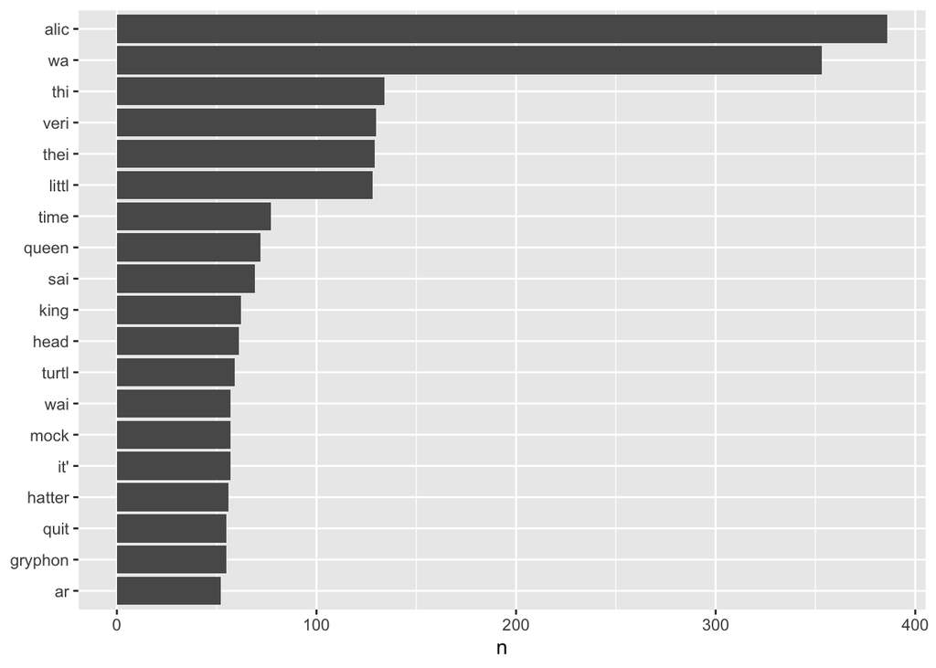

```r
  ggplot(data = tidy_AAIWL.count, mapping = aes(word, n)) +
          geom_col() +
          xlab(NULL) +
          coord_flip()
```

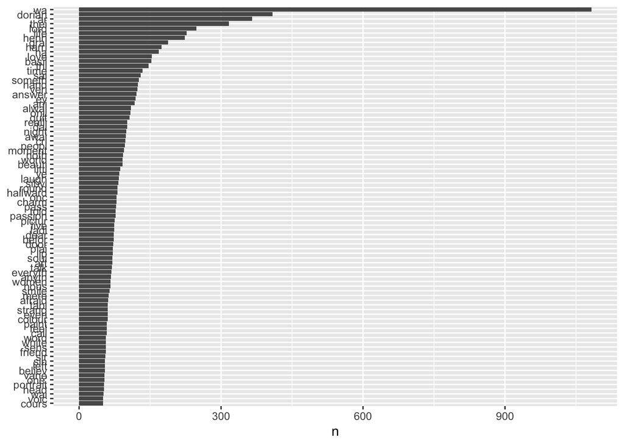

```r
  ggplot(data = tidy_PODG.count, mapping = aes(word, n)) +
          geom_col() +
          xlab(NULL) +
          coord_flip()
```

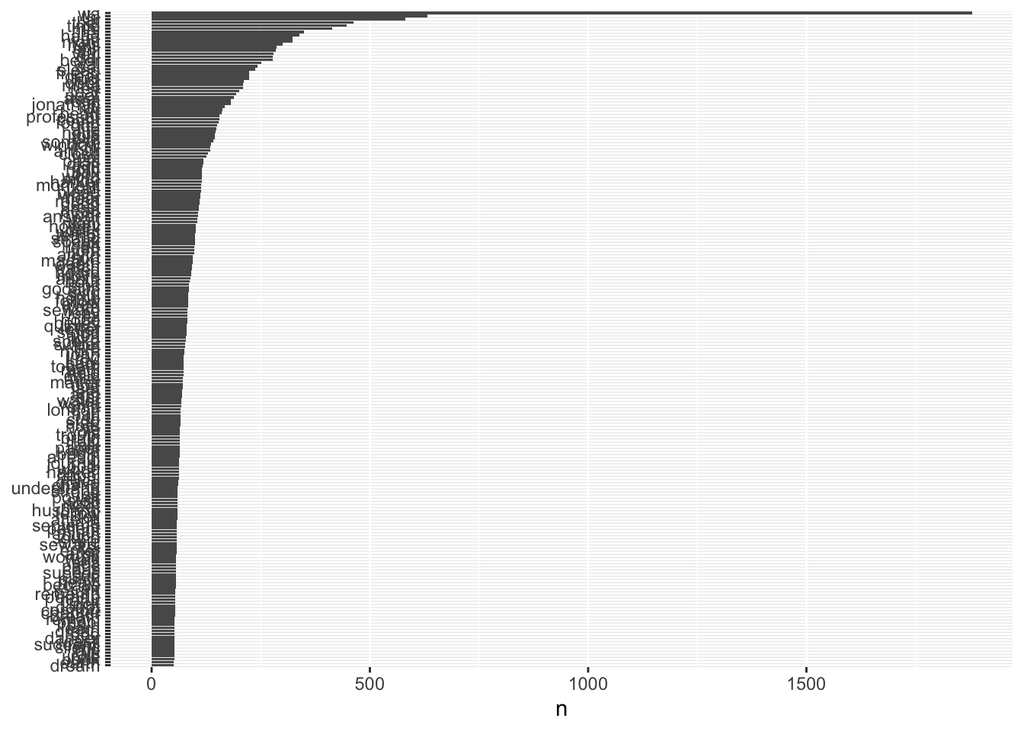

```r
  ggplot(data = tidy_Drac.count, mapping = aes(word, n)) +
          geom_col() +
          xlab(NULL) +
          coord_flip()
```

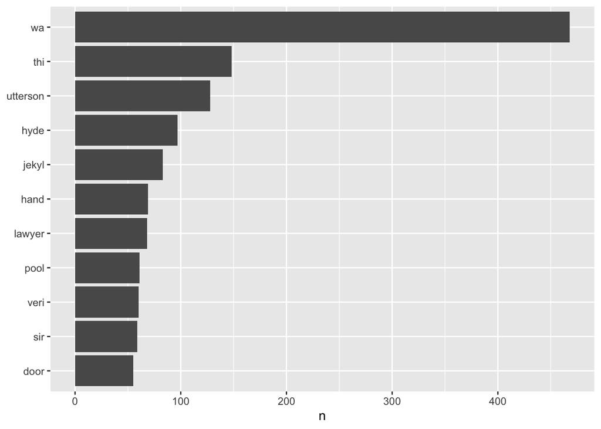

```r
  ggplot(data = tidy_SCJH.count, mapping = aes(word, n)) +
          geom_col() +
          xlab(NULL) +
          coord_flip()
```

The second way to examine word frequency is through an examination where all documents are combined into one data frame. Where both term frequency (*tf*) is combined across all documents which can then be used in combination with the inverse document frequency (*idf*) to determine how importance a word is, in relation to each document within a collection.

Before all text can be combined, it is important to ensure all data frames are correctly labelled. At this time, if you were to combine all the documents, you would see the main idenifier for words from different texts is the `gutenberg_id`, this although is specific to each text, provides very limited information to anyone viewing these data frames. As such it is important to add the name of the book into each data frame.

**Question 9. Add a column, labeled “book” to the tidied text which simply names the book.**

Hint: This can easily be done through using the operator `$` to define a new column in the data frame before adding the name accordingly.

```r
tidy_AAIWL.2$book <- "Alice in Wonderland"
tidy_Drac.2$book <- "Dracula"
tidy_PODG.2$book <- "Picture of Dorian Gray"
tidy_SCJH.2$book <- "Dr. Jekyll and Mr. Hyde"
```

**Question 10. Swapping your code with others in your group, combine all four tided texts together, into one document called “tidy_text”**

```r
tidy_text <- rbind(tidy_AAIWL.2, tidy_Drac.2, tidy_PODG.2, tidy_SCJH.2)
```

Now that the books have been combined, you can now examine again the frequency of different words and the total amount of words per book. To do this, after grouping the data frame by book (using the `group_by()` function), you will need to find the frequency of each word, again using the `count()` function. Secondly, you will also need to find the total number of words per book, this can be done simply through the `summarize()` function. Before being combined together to form a new data frame which details the frequency of each word and the total number of overall words per book. Calculating this is important, as this can then be plotted to determine how common highly occurring words are, compared to rare or unique terms.

**Question 11. Using the code template below, create a plot to indicate the Term Frequency Distribution across these books**

```r
tidy.text.count <- tidy_text %>%
  group_by(??) %>%
  count(??, ??, sort = TRUE)

tidy.text.total <- tidy.text.count %>%
  group_by(??) %>%
  summarize(total = sum(??))

tidy.text.tf <- left_join(tidy.text.count, tidy.text.total)

ggplot(data = tidy.text.tf, mapping = aes(x = (n/total), fill = book)) +
  geom_histogram(show.legend = FALSE) +
  xlim(NA, 0.0009) +
  facet_wrap(~book, ncol = 2, scales = "free_y")
```

```r
tidy.text.count <- tidy_text %>%
  group_by(book) %>%
  count(book, word, sort = TRUE)

tidy.text.total <- tidy.text.count %>%
  group_by(book) %>%
  summarize(total = sum(n))
tidy.text.tf <- left_join(tidy.text.count, tidy.text.total)
```

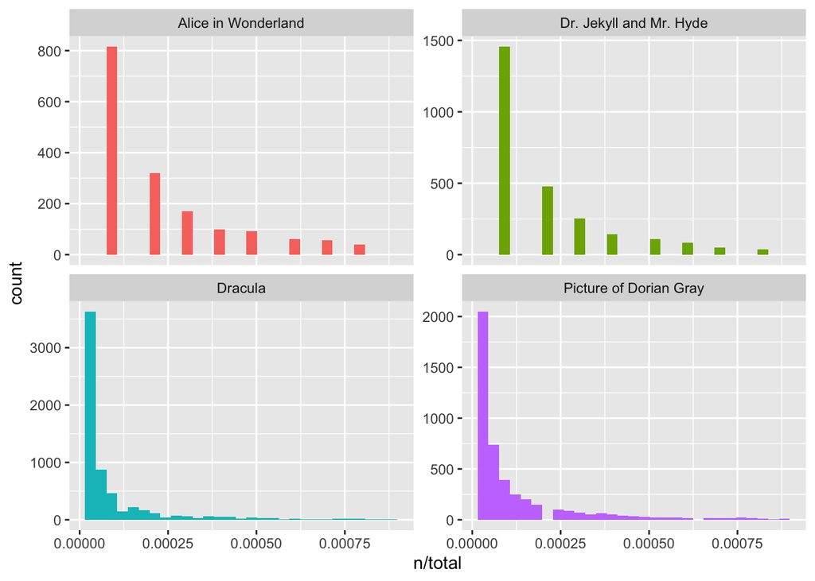

```r
ggplot(tidy.text.tf, aes(n/total, fill = book)) +
  geom_histogram(show.legend = FALSE) +
  xlim(NA, 0.0009) +
  facet_wrap(~book, ncol = 2, scales = "free_y")
```

From this, it is then possible to use the function `bind_tf_idf()` to then determine the *tf*, *idf* and *tf_idf* of the data set.

**Question 12. Using the `bind_tf_idf()` function, and the example code in section 3.3 in the recommended reading, [Text Mining with R](https://www.tidytextmining.com/tfidf.html#term-frequency-in-jane-austens-novels), plot the `tf_idf` across the books.**

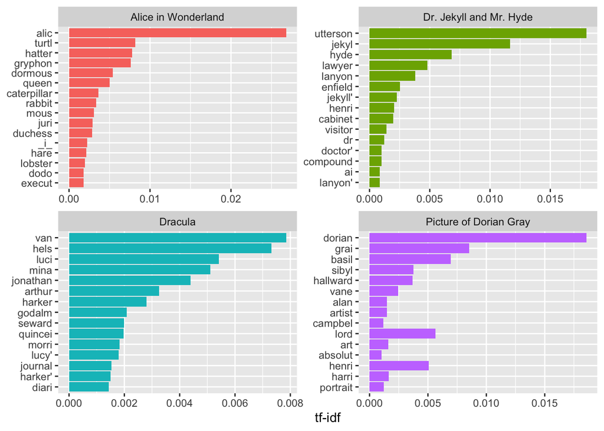

```r
tidy.text.tf <- tidy.text.tf %>%
  bind_tf_idf(word, book, n)

tidy.text.tf %>%
  arrange(desc(tf_idf)) %>%
  mutate(word = factor(word, levels = rev(unique(word)))) %>%
  group_by(book) %>%
  top_n(15) %>%
  ungroup() %>%
  ggplot(aes(word, tf_idf, fill = book)) +
  geom_col(show.legend = FALSE) +
  labs(x = NULL, y = "tf-idf") +
  facet_wrap(~book, ncol = 2, scales = "free") +
  coord_flip()
```

## Word Clouds

Another way to visualize the frequency and occurrence of words in texts is through word clouds. Typically these word clouds can display the most words through their size, with the largest words indicating the most common words.

To plot word clouds, you once again use the frequency data frame as created in Question 7. This can be passed through the function `wordcloud()` (using the pipe (`%>%`) operators), to create a word cloud.

**Question 13. Using the `wordcloud()` function, create a word cloud for your tided text.**

Hint: As with Question 1, ensure to use the piping operator (`%>%`) to easily apply the function. Note: Ensure to use the function `with()`, is used after the piping operator.

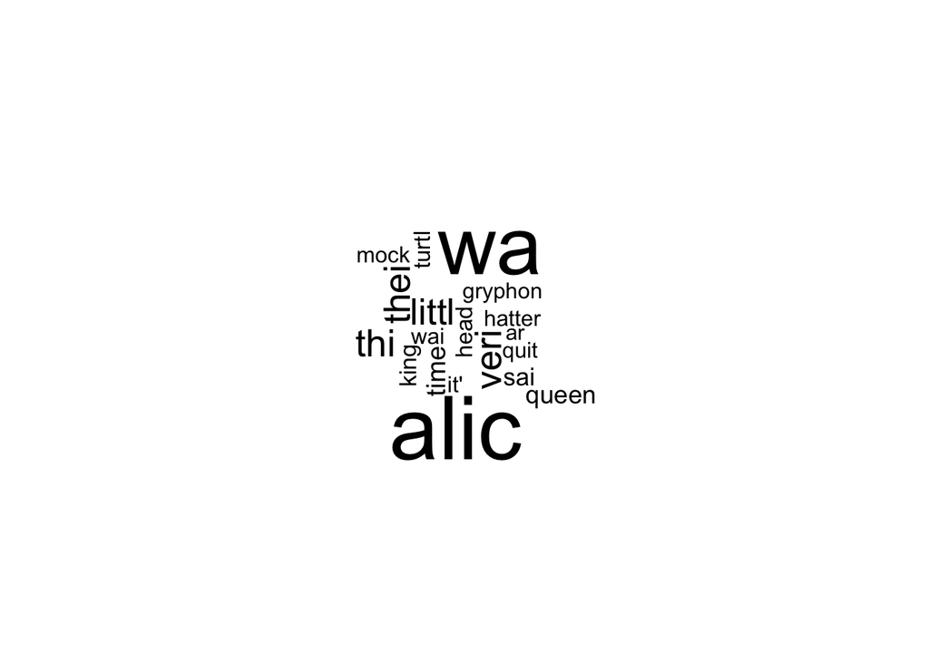

```r
tidy_AAIWL.count %>%
     with(wordcloud(word, n, max.words = 100))
```

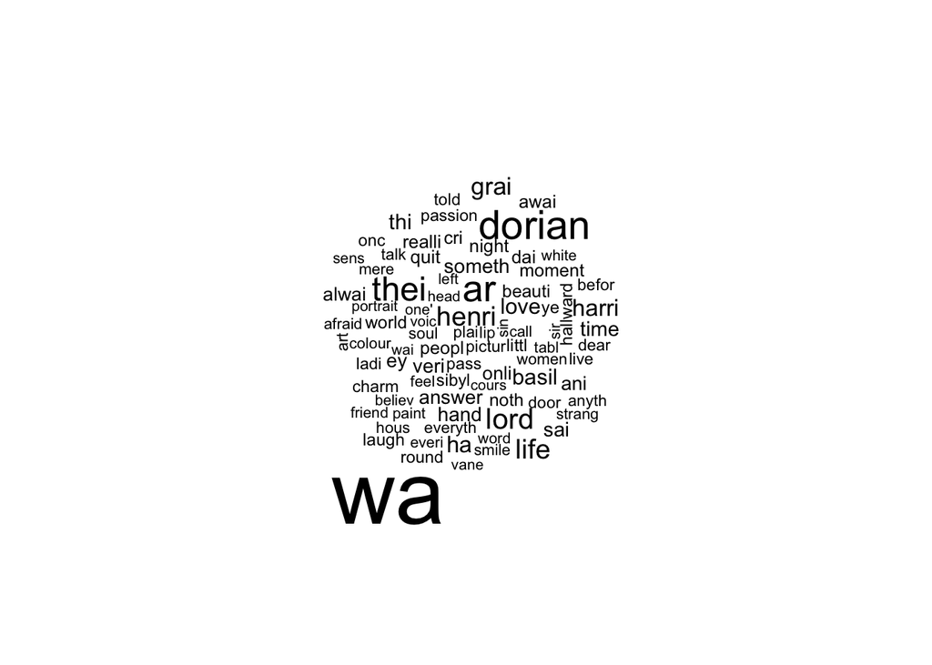

```r
tidy_PODG.count %>%
     with(wordcloud(word, n, max.words = 100))
```

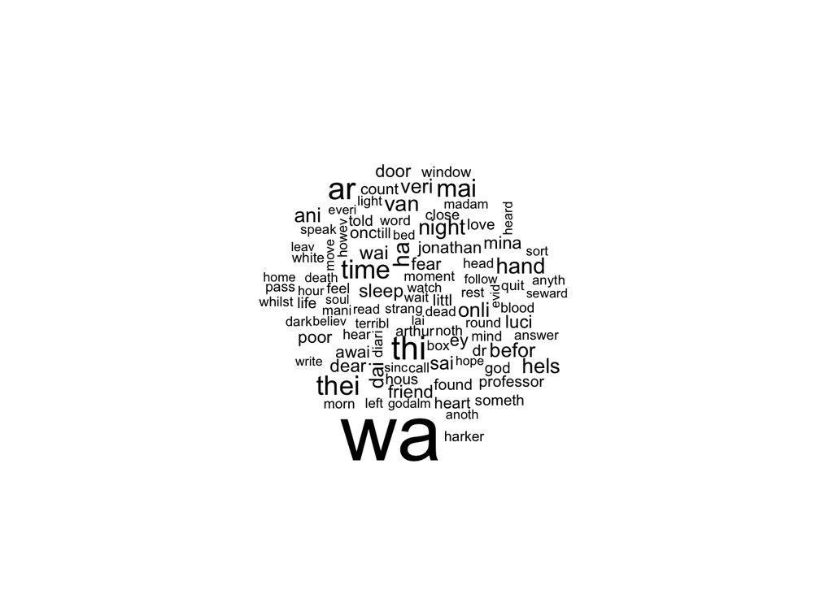

```r
tidy_Drac.count %>%
     with(wordcloud(word, n, max.words = 100))
```

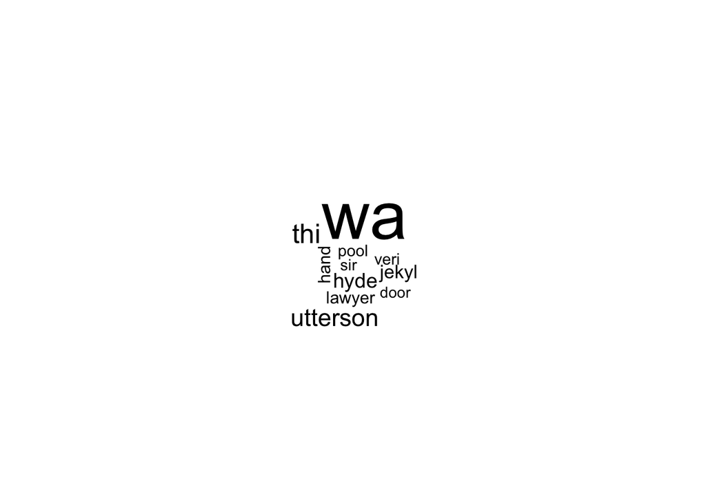

```r
tidy_SCJH.count %>%
  with(wordcloud(word, n, max.words = 100))
```

**Question 14. Discuss with another individual or group, whether you can tell what text each word clouds come from, based on the popular words which occur**

# Analysing Mined Text: Sentiment Analysis

Beyond simply understanding how frequently words occur within text, it is possible to conduct analysis which examines the sentiment of the text. When considering the sentiment of any text it can be used to examine emotions, such as Happy vs Sad, or the association of words with traits such as Good vs Bad. This sentiment analysis can be put to good use when attempting to classify text, whether classifying tweets, blog posts or emails (to determine their content or whether they are Spam). For this practical however, we will focus upon the foundations of sentiment analysis, and whether we can use it to determine what text occurs from the books we have discussed.

Similar to `stop words` and Stemming Algorithms, sentiment analysis is based upon pre-existing dictionaries and methods. Each which have their benefits, the three covered within the recommended reading are `AFINN`, `bing` and `nrc`. Each of these as discussed in the book provides a different analysis of the sentiment in the text. For this practical we will focus on the `nrc` and `AFINN` dictionaries.

Before we conduct a sentiment analysis, let us examine what exists in these dictionaries.

**Question 15. Using the function `get_sentiments()` passing the argument “afinn” or “nrc” to explore the assignment of values to words.**

Note: to access these lexicons you will need to install the package `textdata` as well as the dictionaries fully.

```r
get_sentiments("afinn")

get_sentiments("nrc")
```

Here you can see the main differences between these dictionaries, with `afinn` assigning a value between -5 to +5 indicating the sentiment from negative (-5) to positive (+5). Whereas `nrc` simply classifies the words by a singular emotion.

Given the size of these dictionaries, it is often more effective to conduct a sentiment analysis without having passed any stemming algorithm, especially as you have seen in the case of Porter’s algorithm were pseudo words are made.

**Question 16. Re-Run the previous steps to pre-process the data without using a stemming algorithm.**

Note: As with Question 1, ensure to use the piping operator (`%>%`) to easily apply the function.

```r
tidy_AAIWL.3 <- AAIWL %>%
  mutate(linenumber = row_number(),
         chapter = cumsum(str_detect(text, regex("^chapter [\\divxlc]",
                                                 ignore_case = TRUE)))) %>%
  unnest_tokens(word, text) %>%
  anti_join(stop_words) %>%
  filter(chapter != 0)
tidy_PODG.3 <- PODG %>%
  mutate(linenumber = row_number(),
         chapter = cumsum(str_detect(text, regex("^chapter [\\divxlc]",
                                                 ignore_case = TRUE)))) %>%
  unnest_tokens(word, text) %>%
  anti_join(stop_words) %>%
  filter(chapter != 0)
tidy_Drac.3 <- Drac %>%
  mutate(linenumber = row_number(),
         chapter = cumsum(str_detect(text, regex("^chapter [\\divxlc]",
                                                 ignore_case = TRUE)))) %>%
  unnest_tokens(word, text) %>%
  anti_join(stop_words) %>%
  filter(chapter != 0)
tidy_SCJH.3 <- SCJH %>%
  mutate(linenumber = row_number(),
         chapter = cumsum(str_detect(text, regex("^chapter [\\divxlc]",
                                                 ignore_case = TRUE)))) %>%
  unnest_tokens(word, text) %>%
  anti_join(stop_words)
```

Now that you have a data set which is prepared for sentiment analysis; we can begin the process of conducting a sentiment analysis.

When conducted a sentiment analysis two methods can be used, to begin is with the `nrc` dictionary, the second we can use the `afinn` dictionary.

## Method 1: `nrc`

### Step 1: Select Sentiment Focus

Before beginning any analysis with `nrc`, a focus of the sentiment analysis should be selected. By selecting a focus, this means selecting an emotion which you wish to examine, let us first consider `fear`. To do this you simply need to `filter()` the sentiment to “fear”.

**Question 17. Filter the `nrc` dictionary, to only be listed with the “fear” terms, assigning this to the variable list `nrc_fear`.**

```r
nrc_fear <- get_sentiments("nrc") %>%
  filter(sentiment == "fear")
```

### Step 2: Filtering the Focus

From this you can use the `inner_join()` function passing the argument `nrc_fear` to isolate only the words on this list.

**Question 18. Using the `inner_join()` and `count()` functions to create a list of the fear words and their frequencies within your tided text.**

```r
tidy_AAIWL.3 %>%
  inner_join(nrc_fear) %>%
  count(word, sort = TRUE)
```

```
## # A tibble: 132 x 2
##    word           n
##    <chr>      <int>
##  1 court         19
##  2 mad           16
##  3 change        14
##  4 afraid        12
##  5 serpent        9
##  6 watch          9
##  7 feeling        7
##  8 frightened     7
##  9 broken         6
## 10 dreadfully     6
## # … with 122 more rows
```

```r
tidy_PODG.3 %>%
  inner_join(nrc_fear) %>%
  count(word, sort = TRUE)
```

```
## # A tibble: 345 x 2
##    word         n
##    <chr>    <int>
##  1 afraid      61
##  2 horrible    48
##  3 dreadful    43
##  4 terrible    40
##  5 bad         37
##  6 mad         36
##  7 youth       36
##  8 death       32
##  9 hideous     32
## 10 pain        30
## # … with 335 more rows
```

```r
tidy_Drac.3 %>%
  inner_join(nrc_fear) %>%
  count(word, sort = TRUE)
```

```
## # A tibble: 529 x 2
##    word         n
##    <chr>    <int>
##  1 god        150
##  2 fear       137
##  3 terrible   100
##  4 death       94
##  5 watch       64
##  6 die         45
##  7 change      44
##  8 afraid      41
##  9 doubt       41
## 10 fire        41
## # … with 519 more rows
```

```r
tidy_SCJH.3 %>%
  inner_join(nrc_fear) %>%
  count(word, sort = TRUE)
```

```
## # A tibble: 268 x 2
##    word       n
##    <chr>  <int>
##  1 lawyer    67
##  2 god       22
##  3 fire      18
##  4 evil      17
##  5 death     15
##  6 change    14
##  7 fear      14
##  8 terror    13
##  9 horror    12
## 10 court     11
## # … with 258 more rows
```

## Method 2: `afinn`

### Step 1: Applying Sentiment Ranking

One method of calculating and visualizing sentiment is through a line calculation and determination of how positive or negative a line is. To do this, the first step is to apply the `afinn` dictionary to the passages, using the `inner_join()` function passing the argument `get_sentiments("afinn")` to assign weights to these values.

**Question 20. Using the combined function: `inner_join(get_sentiments("afinn"))`, apply this to your text to apply the weight to the text.**

```r
tidy_AAIWL.3.afinn <- tidy_AAIWL.3 %>%
  inner_join(get_sentiments("afinn"))
tidy_PODG.3.afinn <- tidy_PODG.3 %>%
  inner_join(get_sentiments("afinn"))
tidy_Drac.3.afinn <- tidy_Drac.3 %>%
  inner_join(get_sentiments("afinn"))
tidy_SCJH.3.afinn <- tidy_SCJH.3 %>%
  inner_join(get_sentiments("afinn"))
```

From this you can determine the positive or negative ranking per sentence through running the following code:

**Question 21. Run the following code for your tided text, to create a weight per line ranking the positive or negative rating**

```r
  group_by(linenumber) %>%
  mutate(sentiments = sum(value)) %>%
  distinct(linenumber, .keep_all = T)
```

```r
tidy_AAIWL.3.sent <- tidy_AAIWL.3.afinn %>%
  group_by(linenumber) %>%
  mutate(sentiments = sum(value)) %>%
  distinct(linenumber, .keep_all = T)

tidy_PODG.3.sent <- tidy_PODG.3.afinn %>%
  group_by(linenumber) %>%
  mutate(sentiments = sum(value)) %>%
  distinct(linenumber, .keep_all = T)

tidy_Drac.3.sent <- tidy_Drac.3.afinn %>%
  group_by(linenumber) %>%
  mutate(sentiments = sum(value)) %>%
  distinct(linenumber, .keep_all = T)

tidy_SCJH.sent <- tidy_SCJH.3.afinn %>%
  group_by(linenumber) %>%
  mutate(sentiments = sum(value)) %>%
  distinct(linenumber, .keep_all = T)
```

### Step 2: Visualising Sentiment

From this, you can create a graph using `ggplot` to display the the relationship between `linenumber` and `sentiments`. Which will allow you to compare the different sentiments visually across these books.

**Question 22. Using your knowledge of `ggplot()`, plot your tidied text to indicate the sentiments per line.**

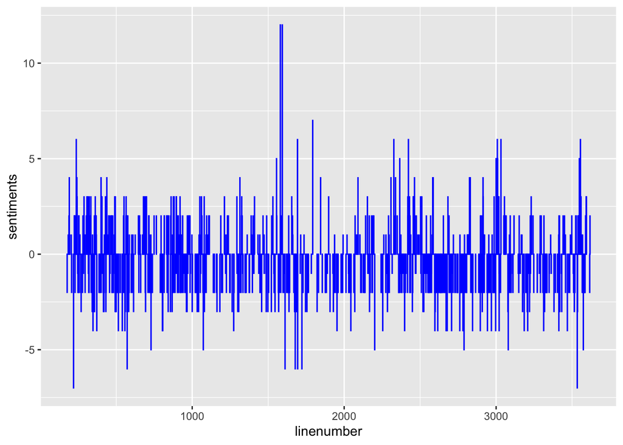

```r
ggplot(data = tidy_AAIWL.3.sent, mapping = aes(x = linenumber, y = sentiments)) +
  geom_col(colour = "blue", show.legend = FALSE)
```

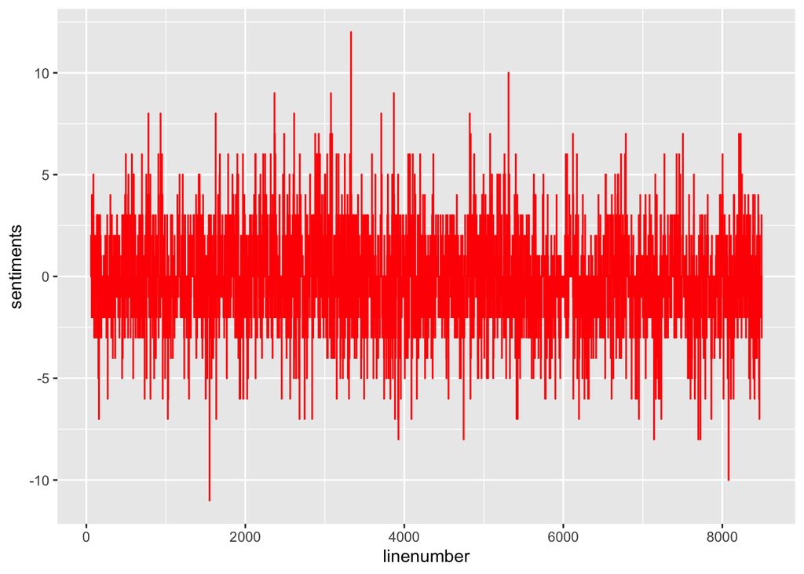

```r
ggplot(data = tidy_PODG.3.sent, mapping = aes(x = linenumber, y = sentiments)) +
  geom_col(colour = "red", show.legend = FALSE)
```

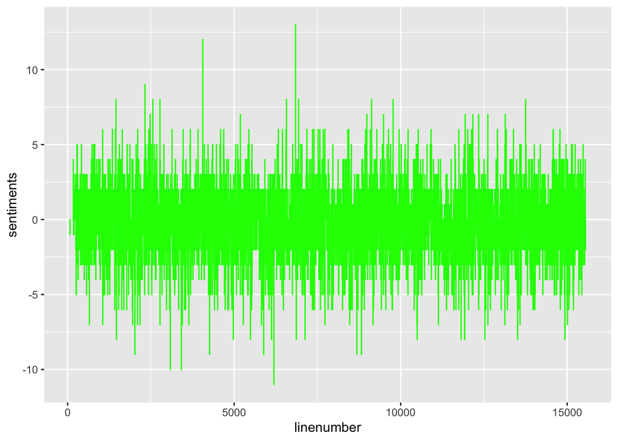

```r
ggplot(data = tidy_Drac.3.sent, mapping = aes(x = linenumber, y = sentiments)) +
  geom_col(colour = "green", show.legend = FALSE)
```

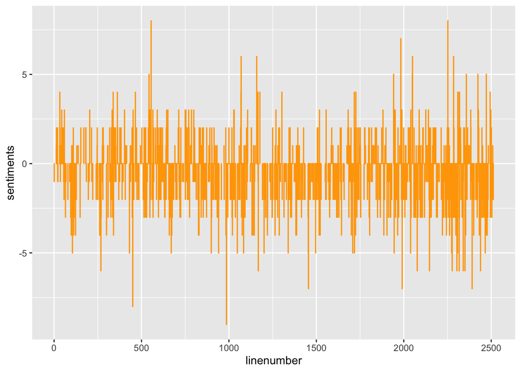

```r
ggplot(data = tidy_SCJH.sent, mapping = aes(x = linenumber, y = sentiments)) +
  geom_col(colour = "orange", show.legend = FALSE)
```

### Step 3: Comparing Visualing Sentiments

**Question 23. Discuss in groups the differences between the different texts, can you tell which graph comes from which text?**